# Your Digest for Monday, Sep 30, 2024 11:59 PM

# what I've learned on 2024-09-30

## 3 things you did well

## 3 things you can do better

# ECG quiz

# what I've learned on 2024-09-30

## 3 things you did well

## 3 things you can do better

# ECG quiz

# management of hyperkalemia

> [!INFO]  
> Standard correction :
> - 10 Units of Insulin IV bolus +  
>   50ml of 50% dextrose.
> - Should cause a decrease of 1mEqL
> - but this is associated with hypoglycaemia in upto 19%.

Insulin should be given alone if the serum glucose is ≥250 mg/dL

> [!NOTE] Avoiding hypoglycaemia

> > To avoid hypoglycemia, we recommend infusion of 10 percent dextrose at 50 to 75 mL/hour after the initial 25 g bolus and close monitoring of blood glucose levels every hour for five to six hours.

Insulin stimulates muscle Na/K ATPase which drives potassium into the muscle cells.

Insulin has this effect only at high concentrations which are achieved by IV boluses. The *hypoglycaemic* effect occurs at lower concentrations and therefore *lasts longer*.

# Guillain barre

# what I've learned on 2024-09-30

## Things to read

- what is the presentation of automimmune encephalitis? What are the EEG findings?
- [ ]

## 3 things you did well

## 3 things you can do better

# ECG quiz

# Causes of increased CPK

**CPK = CK.**

> **creatine is a nitrogenous acid that is synthesised in the liver or ingested as dietary protein**

> **creatine is transported to skeletal muscle and stored in the form of creatine phosphate, where it restores ATP after muscle contraction, before being converted to creatinine by non-enzymatic dehydration**

Creatine Kinase (aka creatinine phosphokinase) is a catalyst for the formation of ATP from ADP via transfer of phosphate from *creatine phosphate (which is an energy reservoir for muscle*.

# Urine cultures

Complications of dysentery include [[General medicine 3#Guillain barre|GBS]], [[2022-SBR-MAY#Reactive arthritis]]

## Review of airway histology

Respiratory epithelium - *ciliated pseudostratified columnar epithelium*.

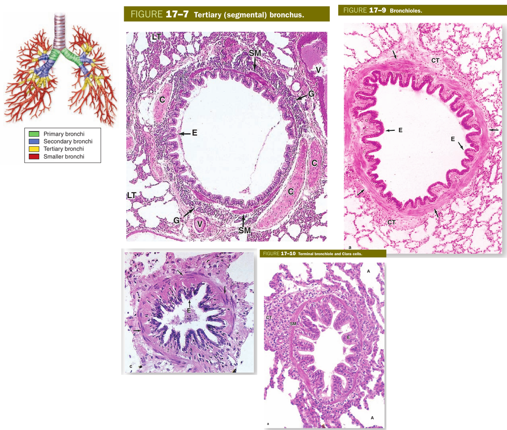

Note the presence of smooth muscle and it's decreasing thickness as the airways become smaller.

**Bronchioles** - intralobular airways < 1mm in diameter arising roughly after the *10th generation of branching*.

### Pathology

> Bronchiectasis is the permanent dilation of bronchi and  
> bronchioles caused by destruction of the muscle and the  
> supporting elastic tissue, resulting from or associated with  
> chronic necrotizing infections. It is not a primary disease  
> but rather *secondary to persisting infection* or obstruction  
> caused by a variety of conditions

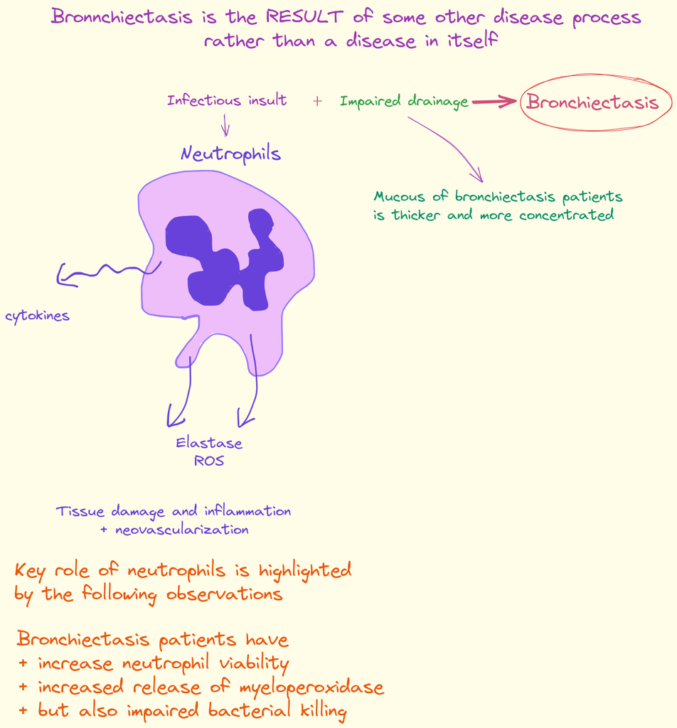

Once patients develop bronchiectasis, most commonly isolated organisms are **haemophillus and pseudomonas and streptococcus pneumoniae**.

**Obstructive impairment** (ie, reduced or normal FVC, low FEV1, and **low FEV1/FVC**) is the most frequent finding on spirometry. ;
$$
\LARGE{Obstruction = ↓\frac{FEV_{1}}{FVC}}
$$

See [[Lung function tests#Obstructive vs. restrictive diseases]]

### Morphology

- Usually affects **bilateral lower lobes**.
- Permanent dilation -> ⭐*small airways are traceable almost upto the pleura*. (in normal lungs, they stop about *2 cm short of the pleura*)
- Chronic inflammatory exudate is seen.
- Extensive desquamation of epithelium causing ulceration.
- Healing is usually by *fibrosis*.
- *Abscesses* can form as complications.

## Management of exacerbations

Control of acute bleeding with **bronchoscopic** local therapy or bronchial artery **embolization.**  
Refractory disease: surgical therapy - ? resection

#2022GM Q21  
#2017GM-OCT/Q10

# Epidemiology

Commoner in **women.**  
Increases with age; marked increase after 60 years.

# Causes of bronchiectasis and basis of disease

### Common causes

**Obstruction** - tumour, lymph nodes, aspiration etc. <- impaired drainage  
**Inherited disorders** -  
Cystic fibrosis #autosomal-Recessive <- impaired clearance of mucous  
Kartagener syndrome <- Ciliary impairement  
Autosomal recessive #autosomal-Recessive  
Situs inversus, [chronic sinusitis](http://emedicine.medscape.com/article/232791-overview), and [bronchiectasis](http://emedicine.medscape.com/article/296961-overview); Underlying pathology is *primary ciliary diskinesia*. Kartagener Xn is a subset of primary ciliary diskinesia (in which patients may not have situs inversus).  
Screening test -> patients have low levels of **nasal nitric oxide**.

Immunoglobulin deficiencies <- recurrent infection  
**Necrotizing of suppurative pneumonia** - staph aureus or klebsiella <- scarring and impaired clearance; ?exagerrated neutrophil response

#### Cystic fibrosis

- #autosomal-Recessive ; requires two mutated copies of the CFTR gene involved in chloride and bicarbonate transport.
- patients have thick secretions in lungs, GI tract, pancreas and reproductive tract.
- Features: Chronic respiratory tract infections, including pseudomonas.
- Males have obstructive azoospermia due to bilateral absence of vas deferens, allergic bronchopulmonary aspergillosis, **clubbing**, pancreatic insufficiency, hypochloremic alkalosis, rectal prolapse and others.
- Sperms express CFTR and spermatogenesis may be reduced.
- Diagnosis: elevated sweat chloride, abnormal nasal potential difference.

#### Other causes

Young syndrome - similar to CF but no evidence of CF; rare diagnosis nowadays.  
Associated with two rheumatic disorders - *Sjogren syndrome and Rheumamtoid arthritis.*  
[[General Medicine 1#Allergic bronchopulmonary aspergillosis|Allergic bronchopulmonary aspergillosis]] - ? central bronchiectasis